# Stock Price Analysis during Dividends announcements

Sai Sandeep Chandaluri

## **Question**

We are interested to learn how stocks perform in terms of excess rates of return when they are actually paying a dividend. (The cum to ex-dates are noted for each stock in CRSP.) What happened to the stock return (minus the S&P500 on the same day) from days -20 through day +20, each day by day? Line up all stock excess returns on the event dates, and calculate the mean across all stock-days. This is the day 0 event mean excess rate of return. Eventually, your result will be 41 mean excess rates of return, that you can graph with relative day on the x-axis and mean rate of return (across all excess returns) on the y-axis. You can do this assignment only for calendar years after 2010 to make it simpler. (O: How does each stock’s rate of return relate to the amount of the dividend it actually paid?).

## **Computation Methodology**

**1. Choosing the right data:**

All the data for carrying out this work have been taken from WRDS. We have taken the CRSP Daily stock data that includes stock information like PERMNO, Avg Bid/Ask Price on each Date, Dividend Declaration date, Payment Date, Record Date, Value weighted S&P 500 return (along with Dividends) etc.

The following is the path of data on WRDS: CRSP -> Annual Update -> Stock -> Security Files -> CRSP Daily Stock

**2. Data Transformation:**

Stock Daily Returns and Excess returns are computed using the following formulas:

$$Daily\space Stock\space Return = \frac{Current\space Price - Previous\space Price}{Previous\space Price}$$
$$Excess\space Return = Daily\space Stock \space Return - Daily\space S\&P\space Return$$

Also, stocks with abnormal returns are considered to be stock consolidations and are ignored while doing above computations. Once the excess returns for all the 41 days (-20 to 20) across each dividend data are computed for each stock, the mean across each of the stocks based on day from dividend is computed. Then, the mean of the day from dividend wise returns for all the stocks are computed to get the final output.

$$R_j = \frac{\Sigma{r_{ij}}}{N}$$
where $R_j$: Mean Excess Return on j day from dividend date, $r_{i,j}$: Mean Excess Return on j day from dividend for Stock $i$ and $N$: Number of Stocks

**4. Results:**

The final plot of excess daily returns based on days from dividend is obtained as below:

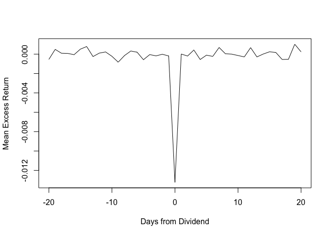

## **Code to compute the returns**

```r
library(data.table)
library(tidyverse)
library(magrittr)
library(xts)
library(dplyr)
library(prettydoc)
library(lubridate)
library(xtable)
library(kableExtra)
library(readxl)
options(xtable.comment = FALSE)

begindate = as.Date("2009-12-01")
divcutdate = as.Date("2009-12-31")
enddate = as.Date("2019-12-31")

#read the data, beginning with the S&P
#stock data
stockdata = read_excel('~/Documents/Documents/Decision Making/hw2data.xlsx')
colnames(stockdata) = c("PERMNO", "Date", "Declaration Date", "Payment Date", "Record Date", "Price", "vwretd_div", "vwretd_no_div")

stockdata$Price = abs(stockdata$Price)

stockdata <- as.data.table(stockdata)
stockdata[, Date:=as.Date(as.character(Date), format = "%Y%m%d")]

stockdata[, `Declaration Date`:=as.Date(as.character(`Declaration Date`), format = "%Y%m%d")]
stockdata[, `Payment Date`:=as.Date(as.character(`Payment Date`), format = "%Y%m%d")]
stockdata[, `Record Date`:=as.Date(as.character(`Record Date`), format = "%Y%m%d")]

stockdata <- stockdata[complete.cases(stockdata[ , 6]),]

stockdata = stockdata[Date %between% c(begindate, enddate),]


listdata <- list()

for (i in 1:length(unique(stockdata$PERMNO))) {
  listdata[[i]] <- stockdata[stockdata$PERMNO == unique(stockdata$PERMNO)[i],]
  if (nrow(listdata[[i]]) > 41) {
  tempdata1 <- listdata[[i]][1:20,]
  tempdata2 <- listdata[[i]][21:(nrow(listdata[[i]])-20),]
  tempdata3 <- listdata[[i]][(nrow(listdata[[i]])-19): nrow(listdata[[i]]),]
  tempdata1$`Record Date` = NULL
  tempdata3$`Record Date` = NULL
  listdata[[i]] <- rbind(tempdata1, tempdata2, tempdata3, fill=TRUE)
  setkey(listdata[[i]], 'Date')
  }
  listdata[[i]] <- listdata[[i]] %>% mutate(Prev_Price = c(NA, listdata[[i]]$Price[-nrow(listdata[[i]])]))
  listdata[[i]] <- listdata[[i]][complete.cases(listdata[[i]][ , 9]),]
  listdata[[i]] <- listdata[[i]] %>% mutate(Stock_Return = (Price - Prev_Price)/Prev_Price)
  listdata[[i]] <- listdata[[i]] %>% mutate(Excess_Return = Stock_Return - vwretd_div)
}

for (i in 1:length(unique(stockdata$PERMNO))) {
  for (j in which(!is.na(listdata[[i]]$`Record Date`))) {
  if (!is.na(listdata[[i]]$Excess_Return[j]) && listdata[[i]]$Excess_Return[j]  > 0.2) {
    listdata[[i]]$Excess_Return[j] = NA
  }
}
}



excess_return_list <- matrix(0, nrow = length(unique(stockdata$PERMNO)), ncol = 41)

for (i in 1:length(unique(stockdata$PERMNO))){
  for (j in 1:41){
    if ((identical(integer(0), which(!is.na(listdata[[i]]$`Record Date`)) - 21 + j) || identical(numeric(0), which(!is.na(listdata[[i]]$`Record Date`)) - 21 + j)) || nrow(listdata[[i]]) < 42 || length(which(!is.na(listdata[[i]]$`Record Date`))) < 4 ) {
  excess_return_list[i,j] <- NA
    }else
  excess_return_list[i,j] <-  mean(listdata[[i]]$Excess_Return[which(!is.na(listdata[[i]]$`Record Date`)) - 21 + j], na.rm = TRUE )
  }
}

mean_excess_return <- list()

for (i in 1:41) {
  mean_excess_return[i] <- mean(excess_return_list[,i], na.rm = TRUE)
}

mean_excess_return_df <- t(as.data.frame(mean_excess_return))



plot(x = -20:20, y =mean_excess_return_df, type='l', xlab = "Days from Dividend", ylab = "Mean Excess Return")
```

# **References**

1. CRSP Daily Stock data from WRDS.